# 2024 ACS Workshop - Designing and Analyzing Agricultural Studies: intro and example in R

This script was developed by Dr. Leonardo Bastos for the **2024 ACS Workshop - Designing and Analyzing Agricultural Studies: intro and example in R**, conducted on May 10th 2024.

# Introduction

The goals of this script are to:

- Create an analytical workflow for an **RCBD** with **random blocks**, from data import through publication-ready plot
- Understand each of its components

# Study details

**Objectives**: Our objective is to assess the effect of different N and K fertilizer rates on crop grain yield.

**Treatment** design: **3 N rate x 3 K rate**.

**Experimental** design: **randomized complete block design** with four blocks.

# a) Setup

Here is where we load the packages we will use.

```r
#install.packages("easypackages")

# Loading packages
library(easypackages)
packages("dplyr") # for data wrangling
packages("tidyr") # for data wrangling
packages("ggplot2") # for plotting
packages("car") # for Anova function
packages("lme4") # for mixed-effect ANOVA model
packages("broom.mixed") # for model residuals extraction
packages("emmeans") # for model mean extraction
packages("multcomp") # for pairwise comparison letter display
```

Let’s import the data.

```r
rcbd_df <- read.csv("../data/wheat_nk_bamyan.csv")

rcbd_df
```

```
   trt rep nrate_kgha krate_kgha yield_kgha
1    1   1          0          0       1350
2    2   1          0         30       2110
3    3   1          0         60       5725
4    4   1        100          0       2988
5    5   1        100         30       3438
6    6   1        100         60       6525
7    7   1        200          0       2825
8    8   1        200         30       4400
9    9   1        200         60       7025
10   1   2          0          0       2250
11   2   2          0         30       4250
12   3   2          0         60       3150
13   4   2        100          0       3575
14   5   2        100         30       6075
```

[output cut: 22 more lines]

We have **36 rows** (9 treatments x 4 blocks).

# b) Explortory data analysis (EDA) - tables

```r
summary(rcbd_df)
```

```
      trt         rep         nrate_kgha    krate_kgha   yield_kgha
 Min.   :1   Min.   :1.00   Min.   :  0   Min.   : 0   Min.   : 812
 1st Qu.:3   1st Qu.:1.75   1st Qu.:  0   1st Qu.: 0   1st Qu.:2630
 Median :5   Median :2.50   Median :100   Median :30   Median :3750
 Mean   :5   Mean   :2.50   Mean   :100   Mean   :30   Mean   :3838
 3rd Qu.:7   3rd Qu.:3.25   3rd Qu.:200   3rd Qu.:60   3rd Qu.:5238
 Max.   :9   Max.   :4.00   Max.   :200   Max.   :60   Max.   :7232
```

Checking variable classes.

```r
glimpse(rcbd_df)
```

```
Rows: 36
Columns: 5
$ trt        <int> 1, 2, 3, 4, 5, 6, 7, 8, 9, 1, 2, 3, 4, 5, 6, 7, 8, 9, 1, 2,…
$ rep        <int> 1, 1, 1, 1, 1, 1, 1, 1, 1, 2, 2, 2, 2, 2, 2, 2, 2, 2, 3, 3,…
$ nrate_kgha <int> 0, 0, 0, 100, 100, 100, 200, 200, 200, 0, 0, 0, 100, 100, 1…
$ krate_kgha <int> 0, 30, 60, 0, 30, 60, 0, 30, 60, 0, 30, 60, 0, 30, 60, 0, 3…
$ yield_kgha <int> 1350, 2110, 5725, 2988, 3438, 6525, 2825, 4400, 7025, 2250,…
```

# c) Wrangling

Need to transform rep, N rate and K rate into factor (for analysis of variance).

```r
rcbd_dfw <- rcbd_df %>%
  mutate(rep = factor(rep),
         nrate_kgha = factor(nrate_kgha),
         krate_kgha = factor(krate_kgha)
         )

rcbd_dfw
```

```
   trt rep nrate_kgha krate_kgha yield_kgha
1    1   1          0          0       1350
2    2   1          0         30       2110
3    3   1          0         60       5725
4    4   1        100          0       2988
5    5   1        100         30       3438
6    6   1        100         60       6525
7    7   1        200          0       2825
8    8   1        200         30       4400
9    9   1        200         60       7025
10   1   2          0          0       2250
11   2   2          0         30       4250
12   3   2          0         60       3150
13   4   2        100          0       3575
14   5   2        100         30       6075
```

[output cut: 22 more lines]

Checking summary.

```r
summary(rcbd_dfw)
```

```
      trt    rep   nrate_kgha krate_kgha   yield_kgha
 Min.   :1   1:9   0  :12     0 :12      Min.   : 812
 1st Qu.:3   2:9   100:12     30:12      1st Qu.:2630
 Median :5   3:9   200:12     60:12      Median :3750
 Mean   :5   4:9                         Mean   :3838
 3rd Qu.:7                               3rd Qu.:5238
 Max.   :9                               Max.   :7232
```

# d) EDA plots

N rate boxplots.

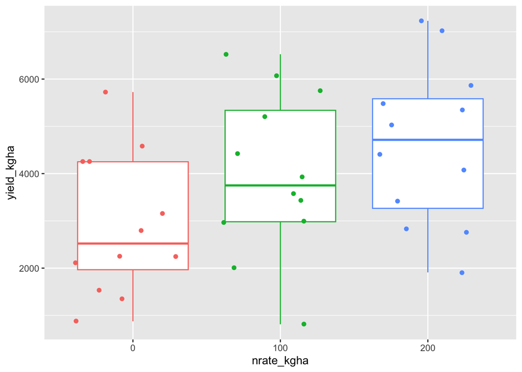

```r
ggplot(rcbd_dfw, aes(x = nrate_kgha,
                    y = yield_kgha,
                    color = nrate_kgha)) +
  geom_boxplot() +
  geom_jitter() +
  theme(legend.position = "none")
```

K rate boxplots.

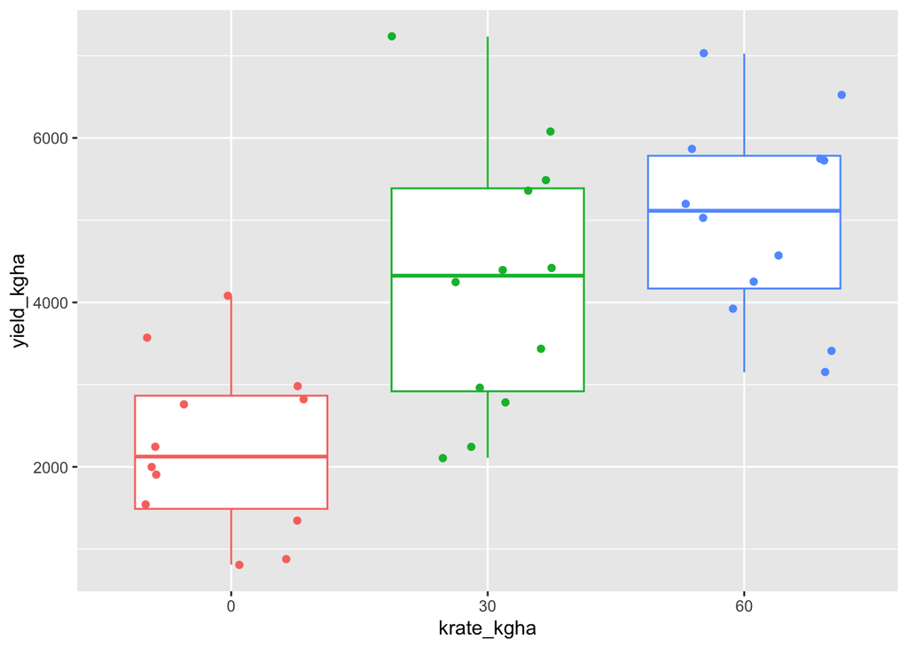

```r
ggplot(rcbd_dfw, aes(x = krate_kgha,
                    y = yield_kgha,
                    color = krate_kgha)) +
  geom_boxplot() +
  geom_jitter() +
  theme(legend.position = "none")
```

N x K interaction boxplots

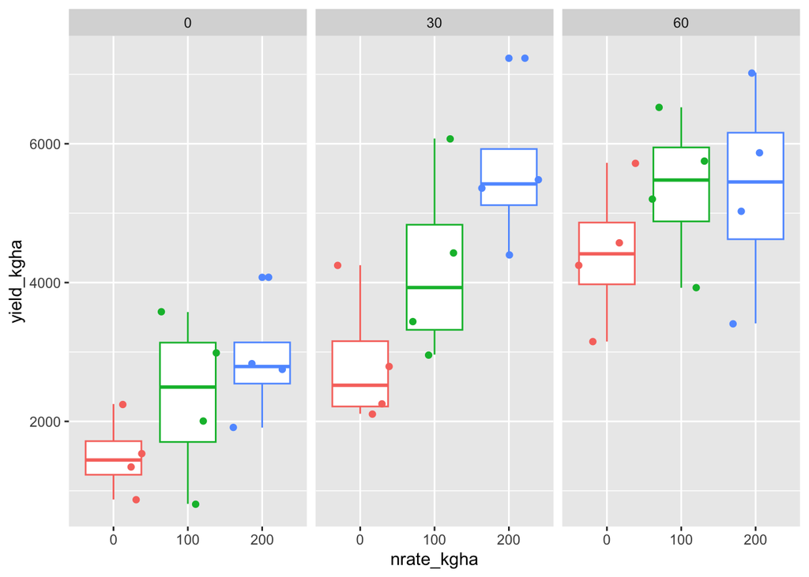

```r
ggplot(rcbd_dfw, aes(x = nrate_kgha,
                    y = yield_kgha,
                    color = nrate_kgha)) +
  geom_boxplot() +
  geom_jitter() +
  facet_grid(.~krate_kgha) +
  theme(legend.position = "none")
```

# e) Statistical model

To treat **blocks as random effect**, we will need to use a function that accomodates fixed and random effects.

To account for more than one variance component (i.e., random effects and error), we can use function `lmer()` from package `lme4`.

```r
# Changing to sum-to-zero contrast
options(contrasts = c("contr.sum", "contr.poly"))

# Model fitting
rcbd_mix_mod <- lmer(yield_kgha ~ (1|rep) + nrate_kgha*krate_kgha,
              data = rcbd_dfw)

rcbd_mix_mod
```

```
Linear mixed model fit by REML ['lmerMod']
Formula: yield_kgha ~ (1 | rep) + nrate_kgha * krate_kgha
   Data: rcbd_dfw
REML criterion at convergence: 481.7932
Random effects:
 Groups   Name        Std.Dev.
 rep      (Intercept)  151.4
 Residual             1118.2
Number of obs: 36, groups:  rep, 4
Fixed Effects:
            (Intercept)              nrate_kgha1              nrate_kgha2
                3837.94                  -911.61                   134.89
            krate_kgha1              krate_kgha2  nrate_kgha1:krate_kgha1
               -1591.78                   392.81                   168.44
nrate_kgha2:krate_kgha1  nrate_kgha1:krate_kgha2  nrate_kgha2:krate_kgha2
                 -37.06                  -468.89                  -142.14
```

# f) ANOVA table

```r
Anova(rcbd_mix_mod, type = 3)
```

```
Analysis of Deviance Table (Type III Wald chisquare tests)

Response: yield_kgha
                         Chisq Df Pr(>Chisq)
(Intercept)           363.9961  1  < 2.2e-16 ***
nrate_kgha             13.9399  2  0.0009397 ***
krate_kgha             39.5932  2  2.526e-09 ***
nrate_kgha:krate_kgha   3.2401  4  0.5184758
---
Signif. codes:  0 '***' 0.001 '**' 0.01 '*' 0.05 '.' 0.1 ' ' 1
```

Notice how rep (i.e., block in this case) does not appear in the ANOVA table above. That’s because it only displays **fixed effects**.

Since only the **main effects (N and K) are significant**, and not the interaction, we should extract means and perform pairwise comparisons for the main effects only.

Before we do that, let’s check our model assumptions.

A model is only valid for inference (i.e., means and pwc) IF it fulfills the linear model assumptions.

# g) Linear model assumptions

## Extracting residuals

First, let’s extract our model residuals, and also create studentized residuals.

```r
rcbd_mix_resid <- augment(rcbd_mix_mod) %>%
  mutate(.studresid = rstudent(rcbd_mix_mod))

rcbd_mix_resid
```

```
# A tibble: 36 × 16
   yield_kgha rep   nrate_kgha krate_kgha .fitted  .resid  .hat  .cooksd .fixed
        <int> <fct> <fct>      <fct>        <dbl>   <dbl> <dbl>    <dbl>  <dbl>
 1       1350 1     0          0            1532.  -182.  0.262 0.00141   1503.
 2       2110 1     0          30           2879.  -769.  0.262 0.0253    2850.
 3       5725 1     0          60           4455.  1270.  0.262 0.0689    4426.
 4       2988 1     100        0            2373.   615.  0.262 0.0161    2344
 5       3438 1     100        30           4253.  -815.  0.262 0.0283    4224.
 6       6525 1     100        60           5380.  1145.  0.262 0.0560    5351
 7       2825 1     200        0            2921.   -95.5 0.262 0.000390  2892.
 8       4400 1     200        30           5648. -1248.  0.262 0.0664    5618.
 9       7025 1     200        60           5363.  1662.  0.262 0.118     5334
10       2250 2     0          0            1557.   693.  0.262 0.0205    1503.
# ℹ 26 more rows
# ℹ 7 more variables: .mu <dbl>, .offset <dbl>, .sqrtXwt <dbl>, .sqrtrwt <dbl>,
#   .weights <dbl>, .wtres <dbl>, .studresid <dbl>
```

Now, let’s recap the linear model assumptions:

- Independence (no pattern)
- Variance homogeneity (homoscedasticity)
- Normality
- Outlier detection (< -3 or > 3)

One difference in mixed models is that the 3 first assumptions are also applied to the **random effects**, so we need to check it for them as well.

### Random effects are iid ~ N(0,var_a)

```r
randeff_rep <- ranef(rcbd_mix_mod)[[1]]

randeff_rep
```

```
  (Intercept)
1   29.038733
2   53.566978
3  -77.528459
4   -5.077252
```

For random effects with so few levels (i.e., 4 since that’s the number of blocks), the QQ plot is one of the only ways to check for assumptions on random effects.

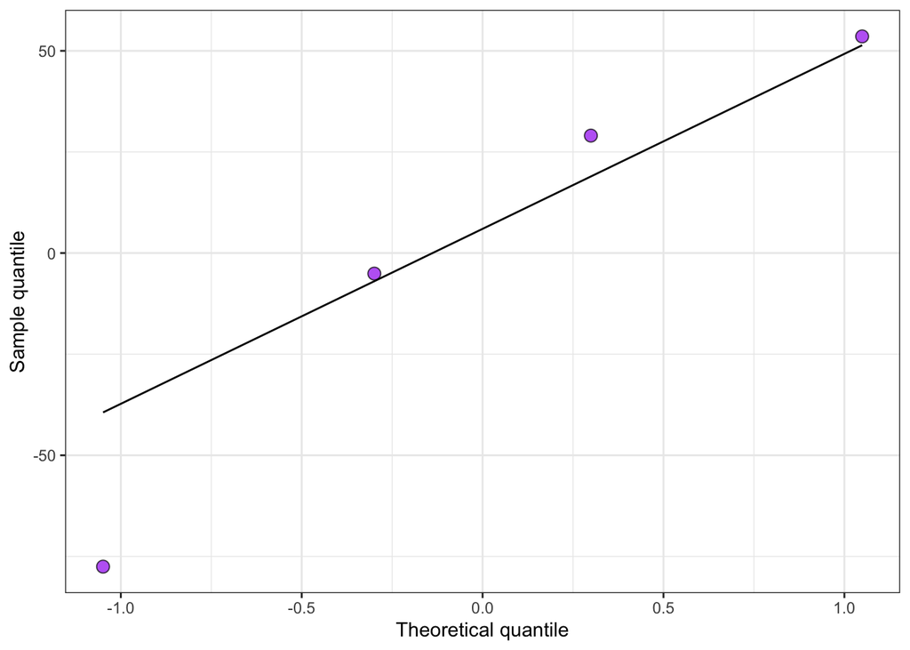

```r
ggplot(randeff_rep, aes(sample = `(Intercept)`)) +
  stat_qq(shape = 21,
          fill = "purple",
          size = 3,
          alpha = .7
  ) +
  stat_qq_line() +
  labs(x = "Theoretical quantile",
       y = "Sample quantile") +
  theme_bw()
```

Nothing to worry here, especially since we only have 4 points.

### Within-group errors are iid ~ N(0, var_e)

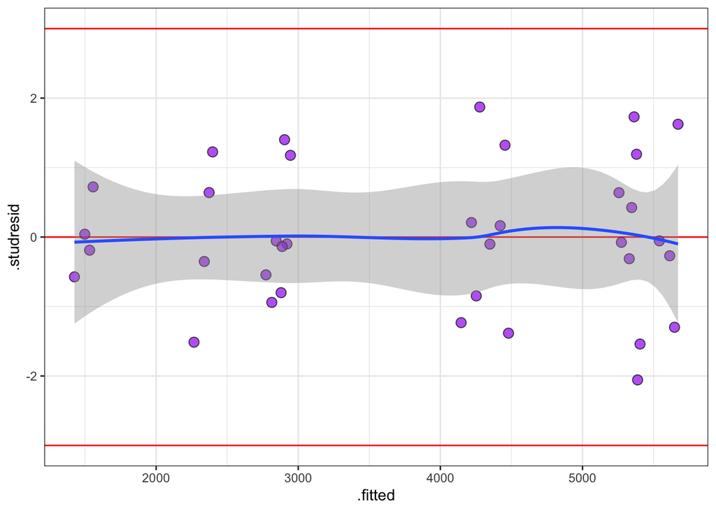

```r
ggplot(rcbd_mix_resid,
       aes(x = .fitted,
           y = .studresid)) +
  geom_hline(yintercept = 0,
             color = "red") +
  geom_point(shape = 21,
             fill = "purple",
             size = 3,
             alpha = .7) +
  geom_smooth() +
  geom_hline(yintercept = c(-3,3),
             color = "red") +
  theme_bw()
```

- **Independence**: no pattern observed, points appear to be random, looks good.
- **Variance homoscedastic**: seems constant across the x-axis (blue smooth line and confidence error ribbon touching 0 on the y-axis throughout the x-axis range), looks good.
- **Outliers**: nothing outside the -3,3 boundaries, looks good.

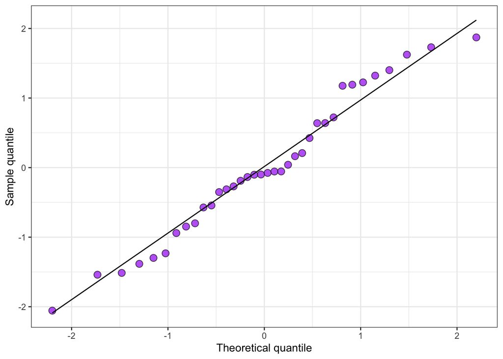

```r
ggplot(rcbd_mix_resid,
       aes(sample = .studresid)) +
  stat_qq(shape = 21,
          fill = "purple",
          size = 3,
          alpha = .7) +
  stat_qq_line() +
  labs(x = "Theoretical quantile",
       y = "Sample quantile") +
  theme_bw()
```

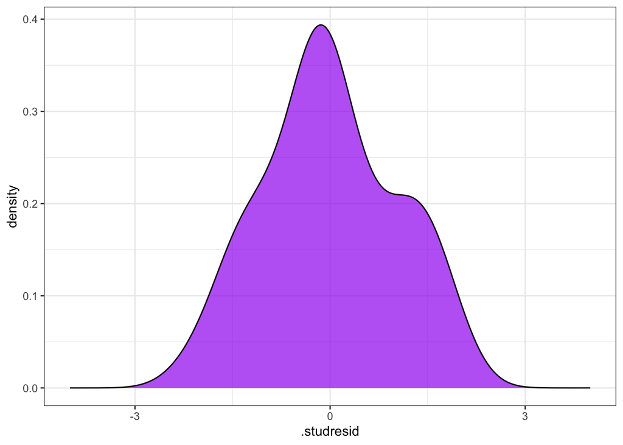

```r
ggplot(rcbd_mix_resid,
       aes(x = .studresid)) +
  geom_density(color = "black",
               fill = "purple",
               alpha = .7) +
  scale_x_continuous(breaks = c(-3,0,3),
                     limits = c(-4,4)) +
  theme_bw()
```

- **Normality**: residuals seem normal.

# h) Model means

The next step in the workflow is extracting the model means.

Since our main effects were the only significant terms, we’ll extract the means for N and K separately.

N rate means:

```r
rcbd_mix_means_n <- emmeans(rcbd_mix_mod, ~nrate_kgha)
```

```
NOTE: Results may be misleading due to involvement in interactions
```

```r
rcbd_mix_means_n
```

```
 nrate_kgha emmean  SE   df lower.CL upper.CL
 0            2926 332 16.2     2224     3629
 100          3973 332 16.2     3271     4675
 200          4615 332 16.2     3912     5317

Results are averaged over the levels of: krate_kgha
Degrees-of-freedom method: kenward-roger
Confidence level used: 0.95
```

K rate means:

```r
rcbd_mix_means_k <- emmeans(rcbd_mix_mod, ~krate_kgha)
```

```
NOTE: Results may be misleading due to involvement in interactions
```

```r
rcbd_mix_means_k
```

```
 krate_kgha emmean  SE   df lower.CL upper.CL
 0            2246 332 16.2     1544     2948
 30           4231 332 16.2     3529     4933
 60           5037 332 16.2     4335     5739

Results are averaged over the levels of: nrate_kgha
Degrees-of-freedom method: kenward-roger
Confidence level used: 0.95
```

# i) Pairwise comparisons

Now that we extracted means, let’s perform pairwise comparisons among them.

N pairwise comparison:

```r
rcbd_mix_pwc_n <- cld(rcbd_mix_means_n,
                   reversed = T,
                   adjust = "none",
               Letters = letters) %>%
  as.data.frame() %>%
  mutate(letter = trimws(.group))

rcbd_mix_pwc_n
```

```
  nrate_kgha   emmean       SE       df lower.CL upper.CL .group letter
1        200 4614.667 331.5619 16.18014 3912.422 5316.911     a       a
2        100 3972.833 331.5619 16.18014 3270.589 4675.078     a       a
3          0 2926.333 331.5619 16.18014 2224.089 3628.578      b      b
```

K pairwise comparison:

```r
rcbd_mix_pwc_k <- cld(rcbd_mix_means_k,
                   reversed = T,
                   adjust = "none",
               Letters = letters) %>%
  as.data.frame() %>%
  mutate(letter = trimws(.group))

rcbd_mix_pwc_k
```

```
  krate_kgha   emmean       SE       df lower.CL upper.CL .group letter
1         60 5036.917 331.5619 16.18014 4334.672 5739.161     a       a
2         30 4230.750 331.5619 16.18014 3528.506 4932.994     a       a
3          0 2246.167 331.5619 16.18014 1543.922 2948.411      b      b
```

# g) Final plots

Let’s plot our results, including both **raw data** (for allowing our audience to inspect data distribution) and **statistical model summary (i.e., letter separation)** for inference purposes.

Let’s make these plots publication ready.

For N rates:

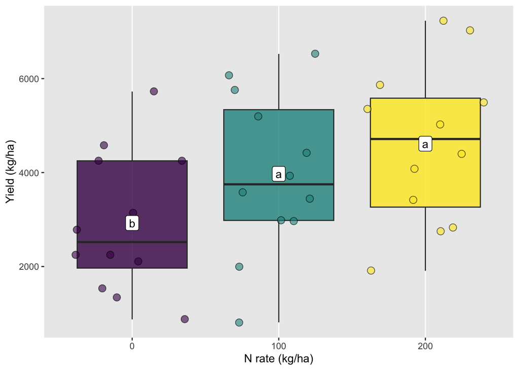

```r
ggplot(mapping = aes(fill = nrate_kgha)) +
  # Raw data and boxplots
  geom_boxplot(data = rcbd_dfw,
               aes(x = nrate_kgha,
                   y = yield_kgha),
               alpha = .8) +
  geom_jitter(data = rcbd_dfw,
               aes(x = nrate_kgha,
                   y = yield_kgha),
              shape = 21,
              size = 3,
              alpha = .6) +
  # Adding letters
  geom_label(data = rcbd_mix_pwc_n,
            aes(x = nrate_kgha,
                y = emmean,
                label = letter),
            fill = "white") +
  labs(x = "N rate (kg/ha)",
       y = "Yield (kg/ha)") +
  scale_fill_viridis_d() +
  theme(panel.grid.major.y = element_blank(),
        panel.grid.minor.y = element_blank(),
        legend.position = "none")
```

For K rates:

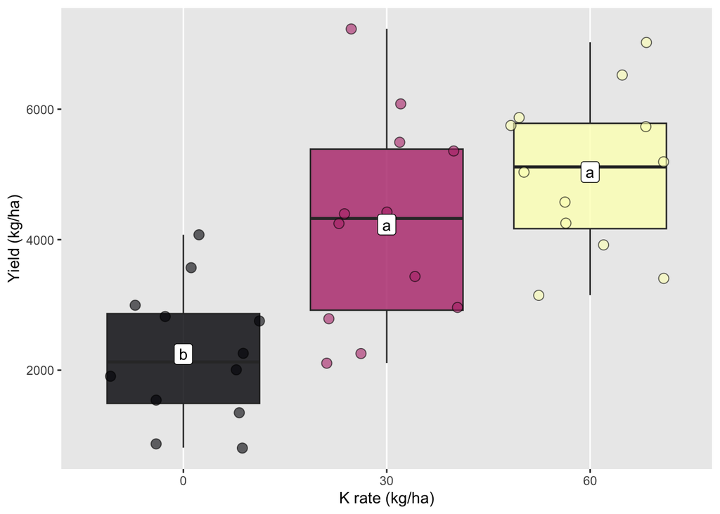

```r
ggplot(mapping = aes(fill = krate_kgha))+
  # Raw data and boxplots
  geom_boxplot(data = rcbd_dfw,
               aes(x = krate_kgha,
                   y = yield_kgha),
               alpha = .8) +
  geom_jitter(data = rcbd_dfw,
               aes(x = krate_kgha,
                   y = yield_kgha),
              shape = 21,
              size = 3,
              alpha = .6) +
  # Adding letters
  geom_label(data = rcbd_mix_pwc_k,
            aes(x = krate_kgha,
                y = emmean,
                label = letter),
            fill = "white") +
  labs(x = "K rate (kg/ha)",
       y = "Yield (kg/ha)") +
  scale_fill_viridis_d(option = "A") +
  theme(panel.grid.major.y = element_blank(),
        panel.grid.minor.y = element_blank(),
        legend.position = "none")
```